# R Notebook

```r
library(tidyverse)
```

# MVP

data is heavily right skewed so might be better to do a log(price). can stablilise variants. can counter fanning out of data from ne (heteroschodasticity)

1. Load the `diamonds.csv` data set and undertake an initial exploration of the data. You will find a description of the meanings of the variables on the relevant [Kaggle page](https://www.kaggle.com/shivam2503/diamonds/)

```r
diamonds <- read_csv("4_diamonds_hw/diamonds.csv")
diamonds
```

| X1 | carat | cut | color | clarity | depth | table | price | x | y | z |
| --- | --- | --- | --- | --- | --- | --- | --- | --- | --- | --- |
| 1 | 0.23 | Ideal | E | SI2 | 61.5 | 55.0 | 326 | 3.95 | 3.98 | 2.43 |
| 2 | 0.21 | Premium | E | SI1 | 59.8 | 61.0 | 326 | 3.89 | 3.84 | 2.31 |
| 3 | 0.23 | Good | E | VS1 | 56.9 | 65.0 | 327 | 4.05 | 4.07 | 2.31 |
| 4 | 0.29 | Premium | I | VS2 | 62.4 | 58.0 | 334 | 4.20 | 4.23 | 2.63 |
| 5 | 0.31 | Good | J | SI2 | 63.3 | 58.0 | 335 | 4.34 | 4.35 | 2.75 |
| 6 | 0.24 | Very Good | J | VVS2 | 62.8 | 57.0 | 336 | 3.94 | 3.96 | 2.48 |
| 7 | 0.24 | Very Good | I | VVS1 | 62.3 | 57.0 | 336 | 3.95 | 3.98 | 2.47 |
| 8 | 0.26 | Very Good | H | SI1 | 61.9 | 55.0 | 337 | 4.07 | 4.11 | 2.53 |
| 9 | 0.22 | Fair | E | VS2 | 65.1 | 61.0 | 337 | 3.87 | 3.78 | 2.49 |
| 10 | 0.23 | Very Good | H | VS1 | 59.4 | 61.0 | 338 | 4.00 | 4.05 | 2.39 |

[output cut: 990 more lines]

```r
summary(diamonds)
```

```
       X1            carat            cut               color
 Min.   :    1   Min.   :0.2000   Length:53940       Length:53940
 1st Qu.:13486   1st Qu.:0.4000   Class :character   Class :character
 Median :26970   Median :0.7000   Mode  :character   Mode  :character
 Mean   :26970   Mean   :0.7979
 3rd Qu.:40455   3rd Qu.:1.0400
 Max.   :53940   Max.   :5.0100
   clarity              depth           table           price
 Length:53940       Min.   :43.00   Min.   :43.00   Min.   :  326
 Class :character   1st Qu.:61.00   1st Qu.:56.00   1st Qu.:  950
 Mode  :character   Median :61.80   Median :57.00   Median : 2401
                    Mean   :61.75   Mean   :57.46   Mean   : 3933
                    3rd Qu.:62.50   3rd Qu.:59.00   3rd Qu.: 5324
                    Max.   :79.00   Max.   :95.00   Max.   :18823
       x                y                z
 Min.   : 0.000   Min.   : 0.000   Min.   : 0.000
 1st Qu.: 4.710   1st Qu.: 4.720   1st Qu.: 2.910
 Median : 5.700   Median : 5.710   Median : 3.530
 Mean   : 5.731   Mean   : 5.735   Mean   : 3.539
 3rd Qu.: 6.540   3rd Qu.: 6.540   3rd Qu.: 4.040
 Max.   :10.740   Max.   :58.900   Max.   :31.800
```

2. We expect the `carat` of the diamonds to be strong correlated with the physical dimensions `x`, `y` and `z`. Use `ggpairs()` to investigate correlations between these four variables.

```r
library(GGally)
```

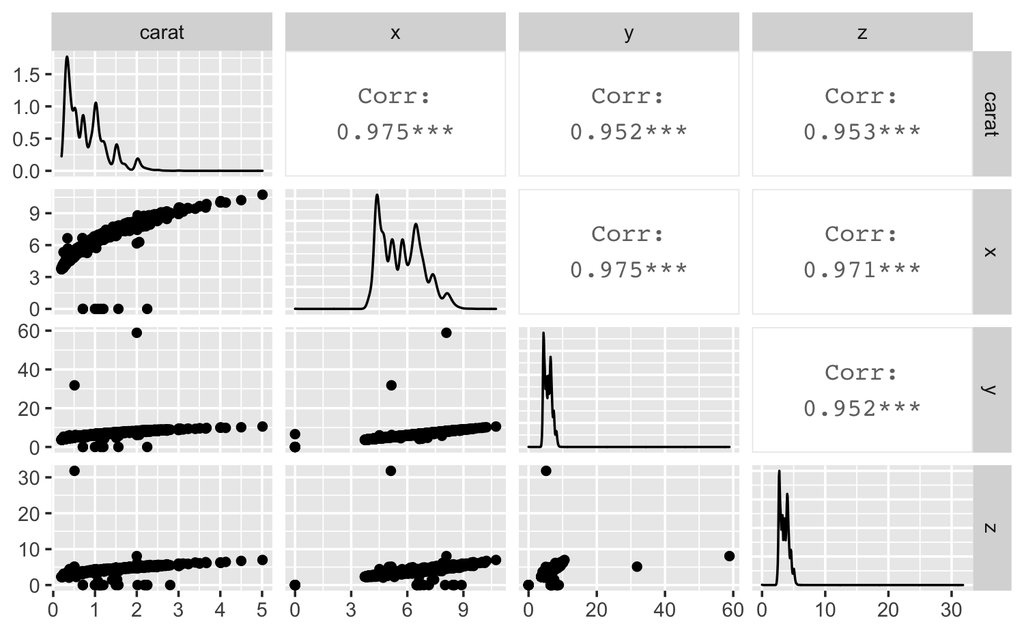

```r
diamonds %>%
select(carat, x, y, z) %>%
  ggpairs()
```

3. So, we do find significant correlations. Let’s drop columns `x`, `y` and `z` from the dataset, in preparation to use only `carat` going forward.

| X1 | carat | cut | color | clarity | depth | table | price |
| --- | --- | --- | --- | --- | --- | --- | --- |
| 1 | 0.23 | Ideal | E | SI2 | 61.5 | 55.0 | 326 |
| 2 | 0.21 | Premium | E | SI1 | 59.8 | 61.0 | 326 |
| 3 | 0.23 | Good | E | VS1 | 56.9 | 65.0 | 327 |
| 4 | 0.29 | Premium | I | VS2 | 62.4 | 58.0 | 334 |
| 5 | 0.31 | Good | J | SI2 | 63.3 | 58.0 | 335 |
| 6 | 0.24 | Very Good | J | VVS2 | 62.8 | 57.0 | 336 |
| 7 | 0.24 | Very Good | I | VVS1 | 62.3 | 57.0 | 336 |
| 8 | 0.26 | Very Good | H | SI1 | 61.9 | 55.0 | 337 |
| 9 | 0.22 | Fair | E | VS2 | 65.1 | 61.0 | 337 |
| 10 | 0.23 | Very Good | H | VS1 | 59.4 | 61.0 | 338 |

[output cut: 990 more lines]

4. We are interested in developing a regression model for the `price` of a diamond in terms of the possible predictor variables in the dataset.
1. Use `ggpairs()` to investigate correlations between `price` and the predictors (this may take a while to run, don’t worry, make coffee or something).

#We examine these plots to look for predictors that appear significantly associated with our response variable (price in this case). We should also take a keen interest in how the predictors correlate with each other.

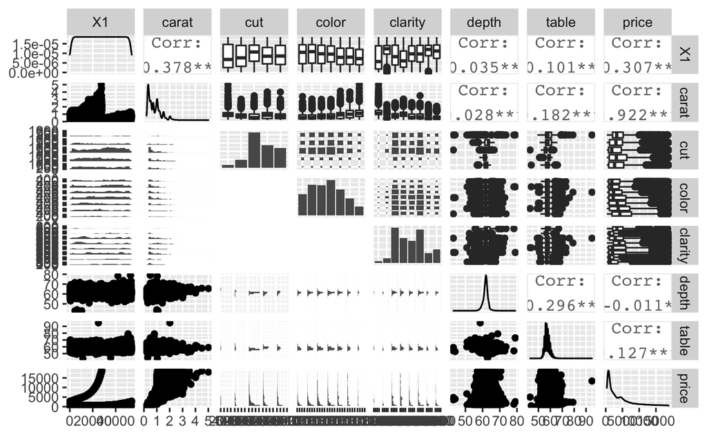

```r
diamonds_clean %>%
  ggpairs()
```

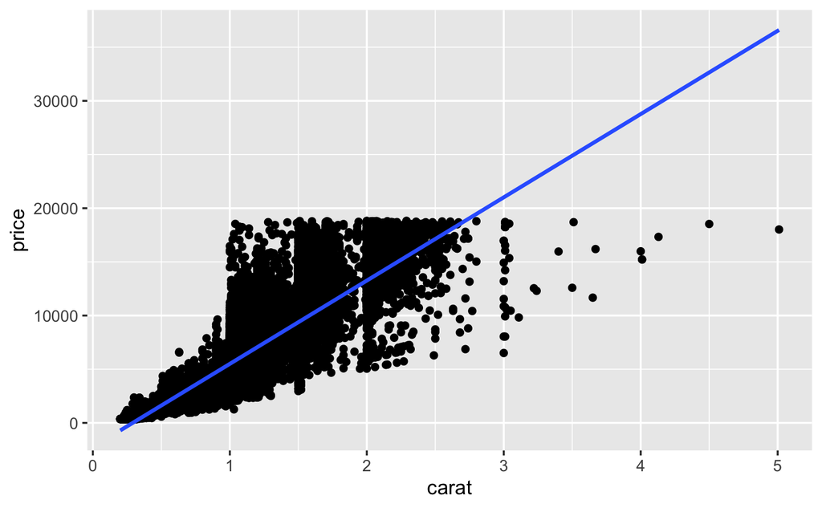

```r
diamonds_clean %>%
  ggplot(aes(x = carat, y = price)) +
  geom_point() +
  geom_smooth(method = "lm", se = FALSE)
```

should have done more:

ie

```r
diamonds_tidy %>%
  ggplot(aes(x = cut, y = price)) +
  geom_boxplot()
```

[output not shown]